# Main Plot

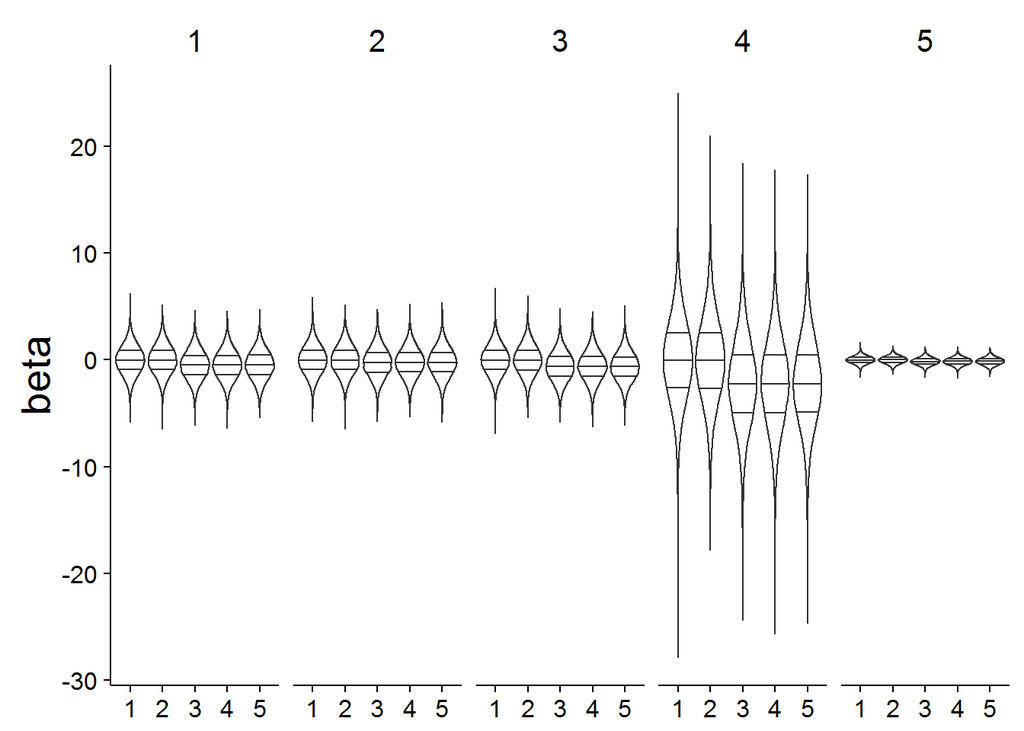

Each violin  
1. True distribution of trends from all simulated populations  
2. Distribution of trends from 2 randomly chosen populations  
3. Distribution of trends from the two populations with the largest abundance at the start of sampling, sampling every year  
4. Same as 3 but sampling every 2 yr  
5. Same as 3 but sampling every 5 yr

First panel, 20 populations  
Second panel, 5 populations  
Third panel, 50 populations  
Fourth panel, more innerannual variablility (CV=0.6)  
Fifth panel, less innerannual variability (CV=0.05)

The three lines in each violine are the 25, 50 and 75 quantiles

10000 simulations go into each bar.

# Populations of Different Sizes

From Trevor

> A more realistic simulation would have populations that differ in mean abundance over time, instead of 20 identical populations. e.g. means of each population drawn from a lognormal with mu and sigma. Three cases: no variability (sigma=0), low inter-population variability (sigma=0.2), and high variability (sigma=0.8). In this case, you still pick the largest populations at the start of the simulations.

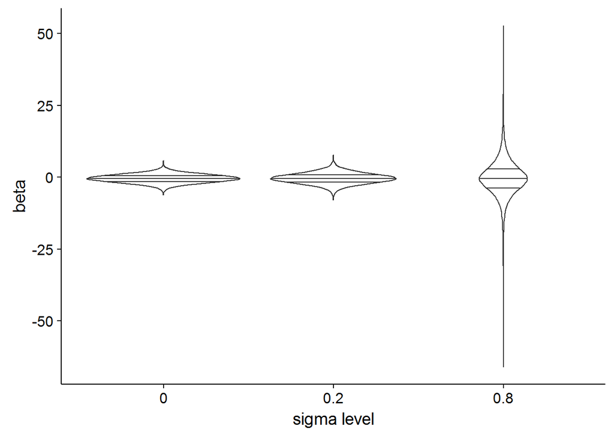

# How to calculate Trends

From Trevor

> It occurred to me that when calculating trends for the entire species, you wouldn’t average the trends of individual populations. Instead you would weight the large populations more, indeed if you were censusing abundance in a bunch of populations, you would add the census numbers up, and then calculate the trend from the summed abundance. This would lead to a greater bias because the declines would be stronger in populations that are large at the start. This would also be important for the case where populations are of different sizes at the start of the simulation.

Correct, but the way I was thinking about this was these are 20 populations of 20 different species at a given place, not 20 sub populations at 20 different places. I can see the argument for doing things either way, but before I go change this I wanted to get feedback from everyone.